# Tarea Regresión - Remuestreo

Armando Olivares

24 de noviembre de 2017

## Práctica de Regresión Lineal y Técnicas de Remuestreo

##### La librería ISLR de R te permite cargar el set de datos Carseats

- Ajusta un modelo de regresión lineal para predecir Sales usando Price, Urban y US.

###### Cargamos las librerías y los datos

```r
suppressWarnings(suppressMessages(library(ISLR)))
suppressWarnings(suppressMessages(library(dplyr)))
suppressWarnings(suppressMessages(library(corrplot)))
suppressWarnings(suppressMessages(library(car)))
suppressWarnings(suppressMessages(library(caret)))
suppressWarnings(suppressMessages(library(PerformanceAnalytics)))
data(Carseats)

glimpse(Carseats)
```

```
## Observations: 400
## Variables: 11
## $ Sales       <dbl> 9.50, 11.22, 10.06, 7.40, 4.15, 10.81, 6.63, 11.85...
## $ CompPrice   <dbl> 138, 111, 113, 117, 141, 124, 115, 136, 132, 132, ...
## $ Income      <dbl> 73, 48, 35, 100, 64, 113, 105, 81, 110, 113, 78, 9...
## $ Advertising <dbl> 11, 16, 10, 4, 3, 13, 0, 15, 0, 0, 9, 4, 2, 11, 11...
## $ Population  <dbl> 276, 260, 269, 466, 340, 501, 45, 425, 108, 131, 1...
## $ Price       <dbl> 120, 83, 80, 97, 128, 72, 108, 120, 124, 124, 100,...
## $ ShelveLoc   <fctr> Bad, Good, Medium, Medium, Bad, Bad, Medium, Good...
## $ Age         <dbl> 42, 65, 59, 55, 38, 78, 71, 67, 76, 76, 26, 50, 62...
## $ Education   <dbl> 17, 10, 12, 14, 13, 16, 15, 10, 10, 17, 10, 13, 18...
## $ Urban       <fctr> Yes, Yes, Yes, Yes, Yes, No, Yes, Yes, No, No, No...
## $ US          <fctr> Yes, Yes, Yes, Yes, No, Yes, No, Yes, No, Yes, Ye...
```

Observando nuestro set de datos notamos que existen variables categóricas como ShelvLoc, Urban y US

## Exploramos nuestro dataset para conocer un poco los datos

Primero las dimensiones:

```r
dim(Carseats)
```

```
## [1] 400  11
```

Luego algunas medidas de tendencia central:

```r
summary(Carseats)
```

```
##      Sales          CompPrice       Income        Advertising
##  Min.   : 0.000   Min.   : 77   Min.   : 21.00   Min.   : 0.000
##  1st Qu.: 5.390   1st Qu.:115   1st Qu.: 42.75   1st Qu.: 0.000
##  Median : 7.490   Median :125   Median : 69.00   Median : 5.000
##  Mean   : 7.496   Mean   :125   Mean   : 68.66   Mean   : 6.635
##  3rd Qu.: 9.320   3rd Qu.:135   3rd Qu.: 91.00   3rd Qu.:12.000
##  Max.   :16.270   Max.   :175   Max.   :120.00   Max.   :29.000
##    Population        Price        ShelveLoc        Age
##  Min.   : 10.0   Min.   : 24.0   Bad   : 96   Min.   :25.00
##  1st Qu.:139.0   1st Qu.:100.0   Good  : 85   1st Qu.:39.75
##  Median :272.0   Median :117.0   Medium:219   Median :54.50
##  Mean   :264.8   Mean   :115.8                Mean   :53.32
##  3rd Qu.:398.5   3rd Qu.:131.0                3rd Qu.:66.00
##  Max.   :509.0   Max.   :191.0                Max.   :80.00
##    Education    Urban       US
##  Min.   :10.0   No :118   No :142
##  1st Qu.:12.0   Yes:282   Yes:258
##  Median :14.0
##  Mean   :13.9
##  3rd Qu.:16.0
##  Max.   :18.0
```

Y la estructura de nuestros datos:

```r
str(Carseats)
```

```
## 'data.frame':    400 obs. of  11 variables:
##  $ Sales      : num  9.5 11.22 10.06 7.4 4.15 ...
##  $ CompPrice  : num  138 111 113 117 141 124 115 136 132 132 ...
##  $ Income     : num  73 48 35 100 64 113 105 81 110 113 ...
##  $ Advertising: num  11 16 10 4 3 13 0 15 0 0 ...
##  $ Population : num  276 260 269 466 340 501 45 425 108 131 ...
##  $ Price      : num  120 83 80 97 128 72 108 120 124 124 ...
##  $ ShelveLoc  : Factor w/ 3 levels "Bad","Good","Medium": 1 2 3 3 1 1 3 2 3 3 ...
##  $ Age        : num  42 65 59 55 38 78 71 67 76 76 ...
##  $ Education  : num  17 10 12 14 13 16 15 10 10 17 ...
##  $ Urban      : Factor w/ 2 levels "No","Yes": 2 2 2 2 2 1 2 2 1 1 ...
##  $ US         : Factor w/ 2 levels "No","Yes": 2 2 2 2 1 2 1 2 1 2 ...
```

Exploramos la correlación de las variables numericas

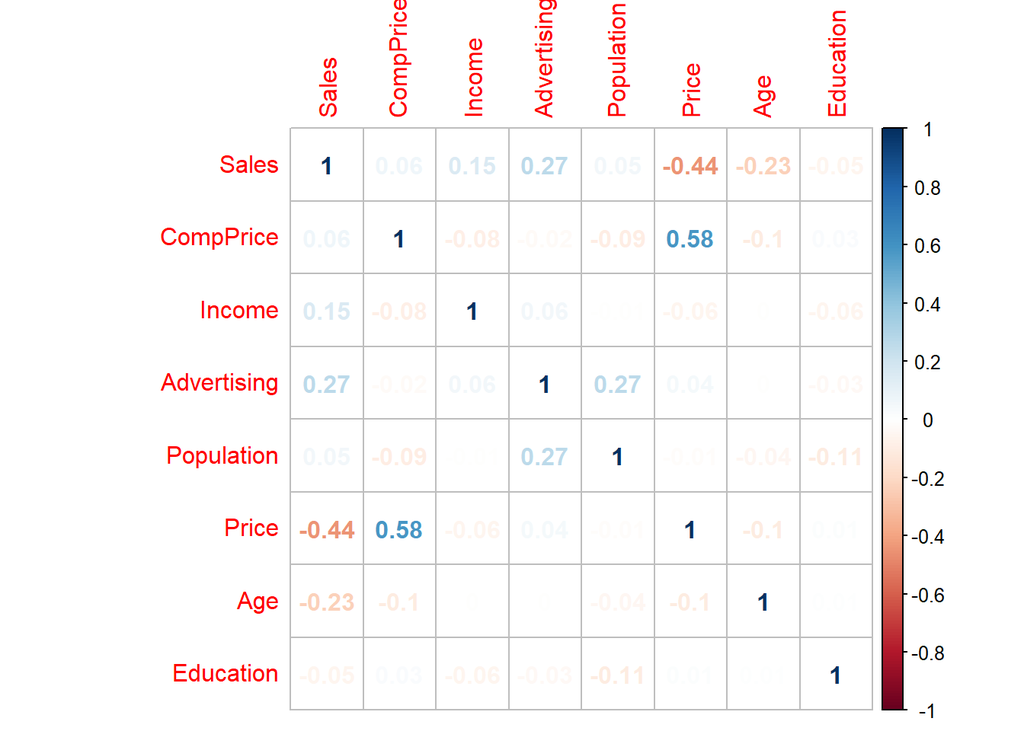

```r
corrplot(cor(select(Carseats, select=-c(ShelveLoc,Urban,US))), method = "number")
```

Del grafico notamos que la correlacion más fuerte es la que existen entre *Sales* y *Price*, también con *Sales* y *Advertising* y *Age*, con las otras variables existe correlacion pero no tan fuerte

## Ajusta un modelo de regresión lineal para predecir Sales usando Price, Urban y US.

```r
#Ajusta un modelo de regresión lineal para predecir Sales usando Price, Urban y US.
modelo1<- lm(Sales ~ Price + Urban + US, data = Carseats)

modelo1
```

```
##
## Call:
## lm(formula = Sales ~ Price + Urban + US, data = Carseats)
##
## Coefficients:
## (Intercept)        Price     UrbanYes        USYes
##    13.04347     -0.05446     -0.02192      1.20057
```

El modelo es

$$Sales = 13.04347 + 1.20057\cdot USYes - 0.05446\cdot Price -0.02192\cdot UrbanYes$$

lo cual implica que a medida que las ventas disminuyen con el aumento del precio y de si la tienda esta ubicada en un entorno Urbano; y las ventas aumentan si la tienda esta ubicada en los EE.UU

### ¿Cuáles de los predictores tienen una relación estadísticamente signifcativa con la variable respuesta? En base a esto, construye un modelo reducido que sólo emplee esos predictores, y compara su bondad de ajuste con el modelo anterior.

### Observamos las variables significativas con el p-valor

```r
summary(modelo1)
```

```
##
## Call:
## lm(formula = Sales ~ Price + Urban + US, data = Carseats)
##
## Residuals:
##     Min      1Q  Median      3Q     Max
## -6.9206 -1.6220 -0.0564  1.5786  7.0581
##
## Coefficients:
##              Estimate Std. Error t value Pr(>|t|)
## (Intercept) 13.043469   0.651012  20.036  < 2e-16 ***
## Price       -0.054459   0.005242 -10.389  < 2e-16 ***
## UrbanYes    -0.021916   0.271650  -0.081    0.936
## USYes        1.200573   0.259042   4.635 4.86e-06 ***
## ---
## Signif. codes:  0 '***' 0.001 '**' 0.01 '*' 0.05 '.' 0.1 ' ' 1
##
## Residual standard error: 2.472 on 396 degrees of freedom
## Multiple R-squared:  0.2393, Adjusted R-squared:  0.2335
## F-statistic: 41.52 on 3 and 396 DF,  p-value: < 2.2e-16
```

**Observamos que las variables significtivas son el *Intercept* (b), *Price* y *USYes*. mientras que la variable *UrbanYes* no es significativa para nuestro modelo**

### Construimos el nuevo modelo reducido

```r
modelo_red <- lm(Sales ~ Price +  US, data = Carseats)
modelo_red
```

```
##
## Call:
## lm(formula = Sales ~ Price + US, data = Carseats)
##
## Coefficients:
## (Intercept)        Price        USYes
##    13.03079     -0.05448      1.19964
```

```r
summary(modelo_red)
```

```
##
## Call:
## lm(formula = Sales ~ Price + US, data = Carseats)
##
## Residuals:
##     Min      1Q  Median      3Q     Max
## -6.9269 -1.6286 -0.0574  1.5766  7.0515
##
## Coefficients:
##             Estimate Std. Error t value Pr(>|t|)
## (Intercept) 13.03079    0.63098  20.652  < 2e-16 ***
## Price       -0.05448    0.00523 -10.416  < 2e-16 ***
## USYes        1.19964    0.25846   4.641 4.71e-06 ***
## ---
## Signif. codes:  0 '***' 0.001 '**' 0.01 '*' 0.05 '.' 0.1 ' ' 1
##
## Residual standard error: 2.469 on 397 degrees of freedom
## Multiple R-squared:  0.2393, Adjusted R-squared:  0.2354
## F-statistic: 62.43 on 2 and 397 DF,  p-value: < 2.2e-16
```

La bondad del ajuste de la recta a los datos se obtiene del Multiple R-squared, que para el modelo1 es **0.2393** y para el modelo reducido (modelo_red) es **0.2393** es decir **no** hay variación, aunque sí mejoró nuestro estadístico F desde **41.52** hasta **62.43**

Los intervalos de confianza para el modelo reducido:

```r
confint(modelo_red)
```

```
##                   2.5 %      97.5 %
## (Intercept) 11.79032020 14.27126531
## Price       -0.06475984 -0.04419543
## USYes        0.69151957  1.70776632
```

### Estudia la existencia de outliers o high leverage points en este último modelo.

Gaficamos los residuos vs las ventas reales:

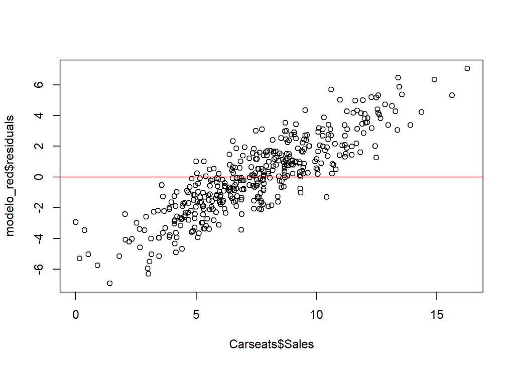

```r
plot(Carseats$Sales, modelo_red$residuals)
abline(0, 0, col="red")
```

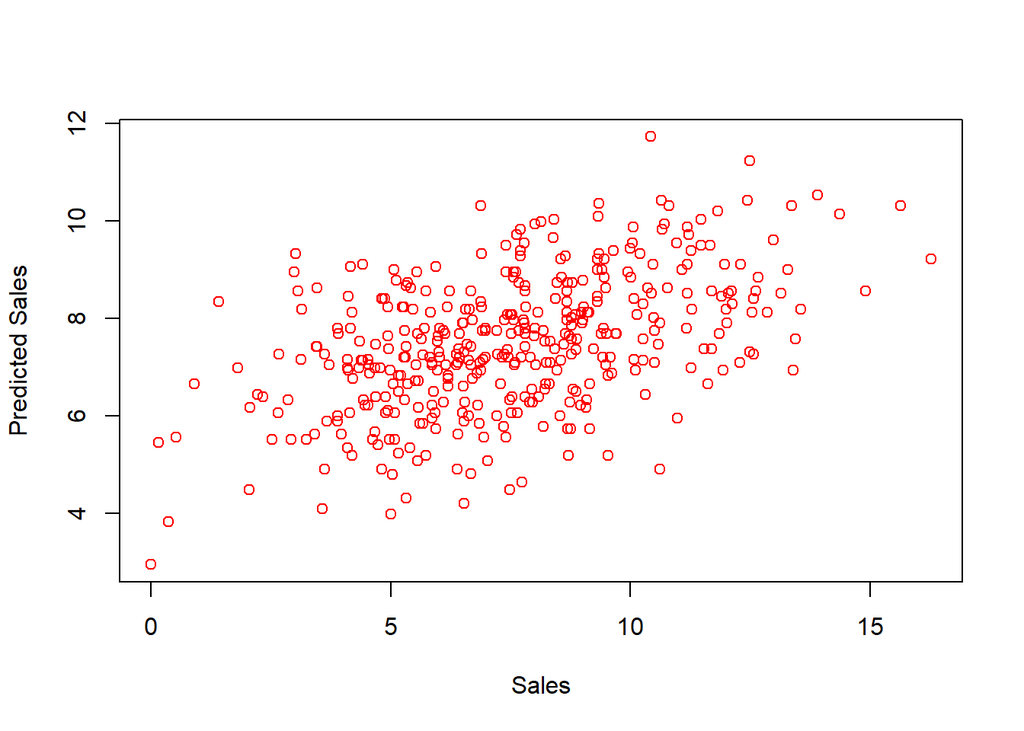

```r
plot(Carseats$Sales, modelo_red$fitted.values, type = 'p', col = 'red', xlab = 'Sales', ylab = 'Predicted Sales')
```

## Examinamos los outliers

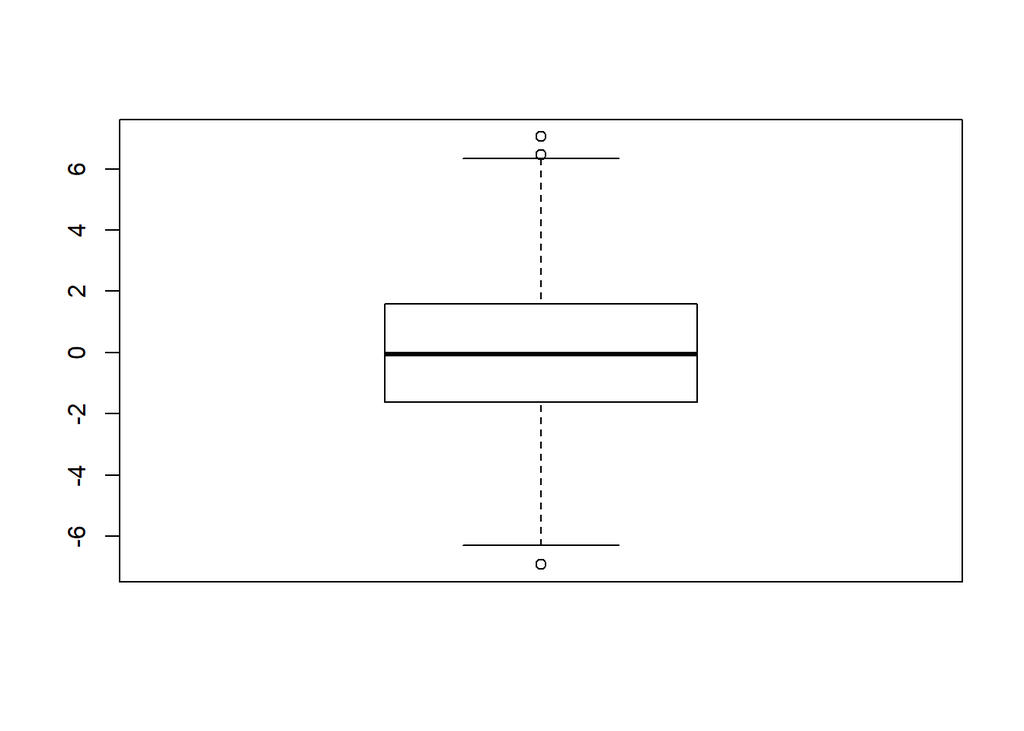

```r
boxplot(modelo_red$residuals)
```

Existen pocos **outliers** en nuestros datos

Observamos los valores de de los residuos graficamente

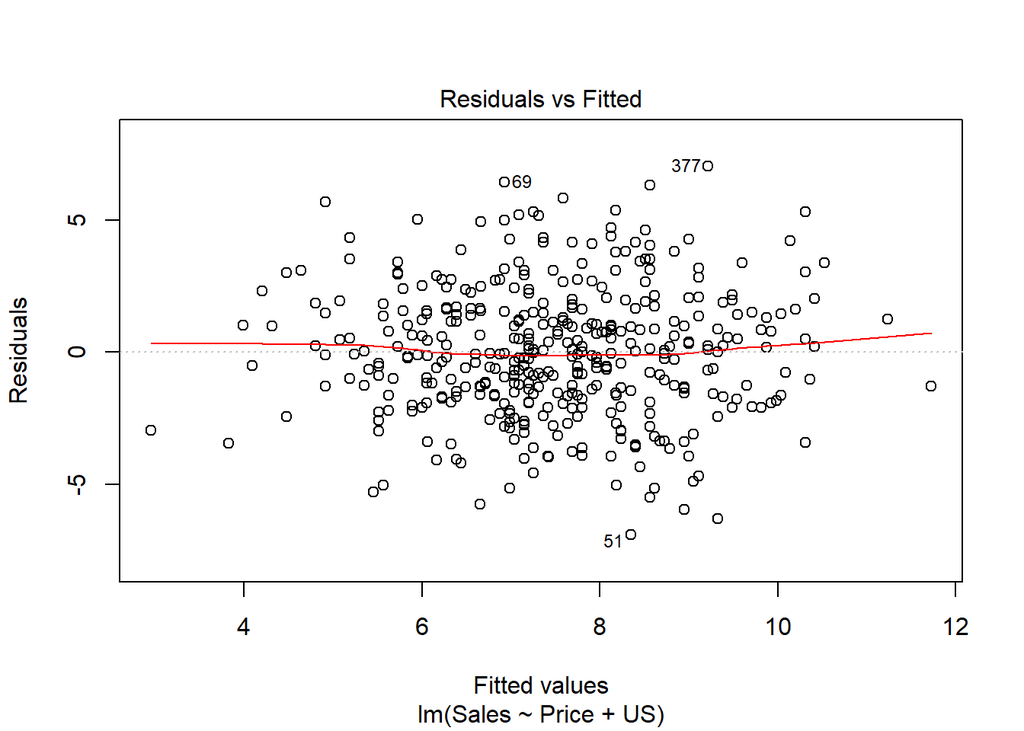

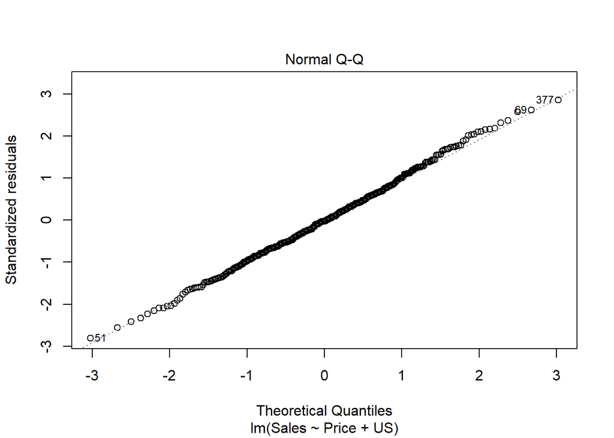

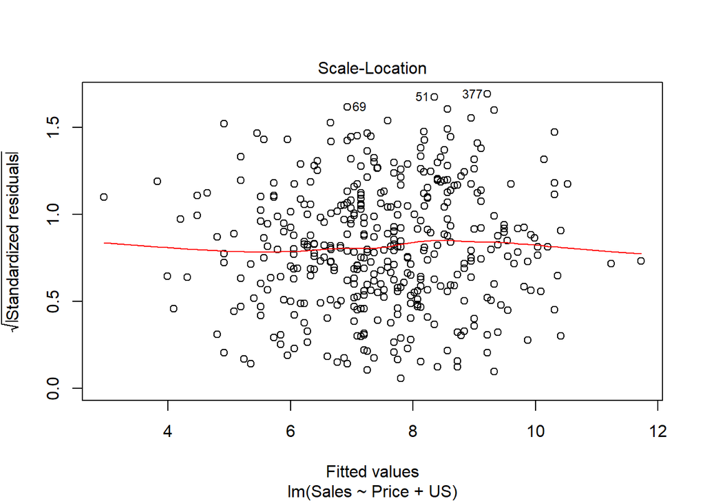

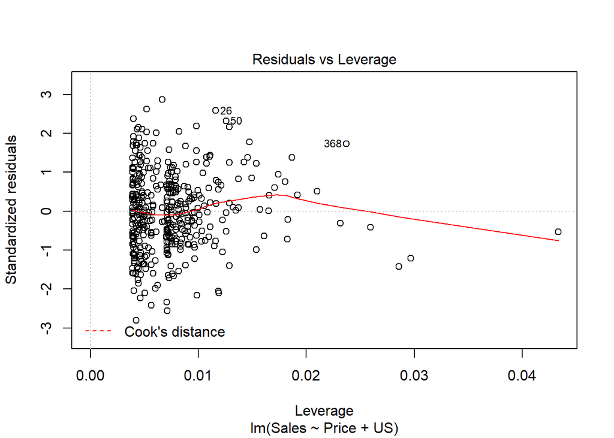

```r
plot(modelo_red)
```

#### Se extrae:

- Del grafico *Residuals vs Fitter* vemos que los residuos presentan aleatoriedad y no siguen patrón alguno
- Del Grafico *Normal Q-Q* vemos que los residuos siguen una normal
- Del grafico *Scale-location* vemos que los residuos estan aleatoriamente distribuidos,
- Del grafico *Residual vs Leverage* observamos que todos los datos caen dentro de la linea de la distancia de Cook, por lo que podemos asumir que no existen outliers que influyan significativamente en nuestro modelo de regresión

#### Por Ultimo Estudiamos la presencia de high-leverage points:

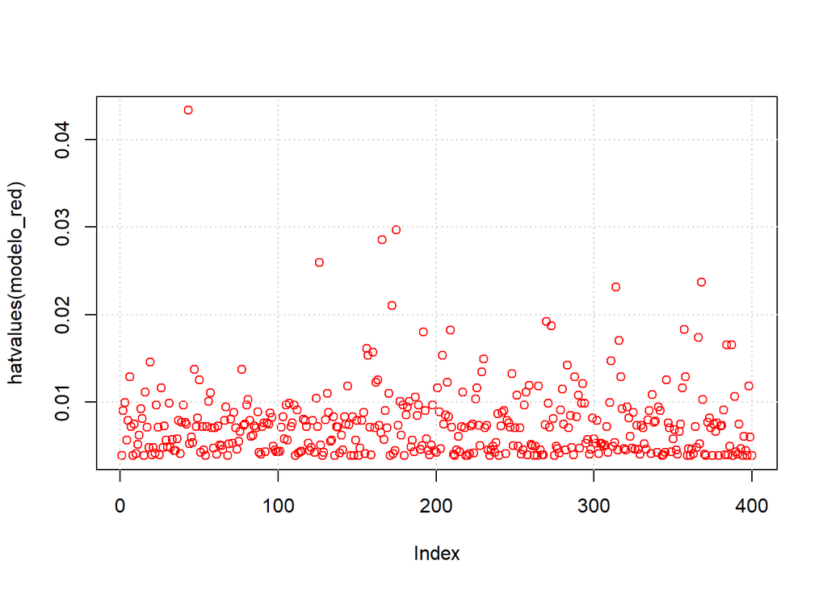

```r
plot(hatvalues(modelo_red), col = 'red')
grid()
```

Podemos decir que los valores por encima de **0.02** son outliers (alrededor de 7 puntos) por lo que si los eliminanos podremos mejorar un poco nuestro modelo, aunque tampoco representan un grave problema porque tampoco influyen significativamente como observamos en las graficas de los residuos

#### Finalmente, estudiamos la colinealidad:

```r
vif(modelo_red)
```

```
##    Price       US
## 1.003359 1.003359
```

las variables **no** son colineales, y Nuestro Modelo es **mejorable**

## Ejercicio 2

##### Del mismo modo, la librería Ecdat de R te permite cargar el set de datos Caschool. Construye un modelo de regresión lineal que permita predecir testscr (debes realizar el análisis completo: desde la exploración inicial de los datos hasta el ajuste del modelo final y la presentación de resultados, pasando por los diferentes pasos que te permitan optimizar tu primer modelo).

#### Cargamos la librerias y los datos

```r
suppressWarnings(suppressMessages(library(Ecdat)))
data("Caschool")
glimpse(Caschool)
```

```
## Observations: 420
## Variables: 17
## $ distcod  <int> 75119, 61499, 61549, 61457, 61523, 62042, 68536, 6383...
## $ county   <fctr> Alameda, Butte, Butte, Butte, Butte, Fresno, San Joa...
## $ district <fctr> Sunol Glen Unified, Manzanita Elementary, Thermalito...
## $ grspan   <fctr> KK-08, KK-08, KK-08, KK-08, KK-08, KK-08, KK-08, KK-...
## $ enrltot  <int> 195, 240, 1550, 243, 1335, 137, 195, 888, 379, 2247, ...
## $ teachers <dbl> 10.90, 11.15, 82.90, 14.00, 71.50, 6.40, 10.00, 42.50...
## $ calwpct  <dbl> 0.5102, 15.4167, 55.0323, 36.4754, 33.1086, 12.3188, ...
## $ mealpct  <dbl> 2.0408, 47.9167, 76.3226, 77.0492, 78.4270, 86.9565, ...
## $ computer <int> 67, 101, 169, 85, 171, 25, 28, 66, 35, 0, 86, 56, 25,...
## $ testscr  <dbl> 690.80, 661.20, 643.60, 647.70, 640.85, 605.55, 606.7...
## $ compstu  <dbl> 0.34358975, 0.42083332, 0.10903226, 0.34979424, 0.128...
## $ expnstu  <dbl> 6384.911, 5099.381, 5501.955, 7101.831, 5235.988, 558...
## $ str      <dbl> 17.88991, 21.52466, 18.69723, 17.35714, 18.67133, 21....
## $ avginc   <dbl> 22.690001, 9.824000, 8.978000, 8.978000, 9.080333, 10...
## $ elpct    <dbl> 0.000000, 4.583333, 30.000002, 0.000000, 13.857677, 1...
## $ readscr  <dbl> 691.6, 660.5, 636.3, 651.9, 641.8, 605.7, 604.5, 605....
## $ mathscr  <dbl> 690.0, 661.9, 650.9, 643.5, 639.9, 605.4, 609.0, 612....
```

#### Exploramos los datos

```r
dim(Caschool)
```

```
## [1] 420  17
```

```r
str(Caschool)
```

```
## 'data.frame':    420 obs. of  17 variables:
##  $ distcod : int  75119 61499 61549 61457 61523 62042 68536 63834 62331 67306 ...
##  $ county  : Factor w/ 45 levels "Alameda","Butte",..: 1 2 2 2 2 6 29 11 6 25 ...
##  $ district: Factor w/ 409 levels "Ackerman Elementary",..: 362 214 367 132 270 53 152 383 263 94 ...
##  $ grspan  : Factor w/ 2 levels "KK-06","KK-08": 2 2 2 2 2 2 2 2 2 1 ...
##  $ enrltot : int  195 240 1550 243 1335 137 195 888 379 2247 ...
##  $ teachers: num  10.9 11.1 82.9 14 71.5 ...
##  $ calwpct : num  0.51 15.42 55.03 36.48 33.11 ...
##  $ mealpct : num  2.04 47.92 76.32 77.05 78.43 ...
##  $ computer: int  67 101 169 85 171 25 28 66 35 0 ...
##  $ testscr : num  691 661 644 648 641 ...
##  $ compstu : num  0.344 0.421 0.109 0.35 0.128 ...
##  $ expnstu : num  6385 5099 5502 7102 5236 ...
##  $ str     : num  17.9 21.5 18.7 17.4 18.7 ...
##  $ avginc  : num  22.69 9.82 8.98 8.98 9.08 ...
##  $ elpct   : num  0 4.58 30 0 13.86 ...
##  $ readscr : num  692 660 636 652 642 ...
##  $ mathscr : num  690 662 651 644 640 ...
```

Nuestro data set contiene 420 observaciones de 17 variables, de las cuales 4 son categóricas

Exploremos las varables categóricas

```r
length(unique(Caschool$county))
```

```
## [1] 45
```

```r
length(unique(Caschool$distcod))
```

```
## [1] 420
```

```r
length(unique(Caschool$district))
```

```
## [1] 409
```

```r
length(unique(Caschool$grspan))
```

```
## [1] 2
```

Como se observa por la cantidad de valores distintos en las variables categóricas *county*, *distcod* y *district* y por el tamaño de nustro dataset decidimos sacar estas variables de nuestro modelo (y para evitar *the curse of dimensionality*)

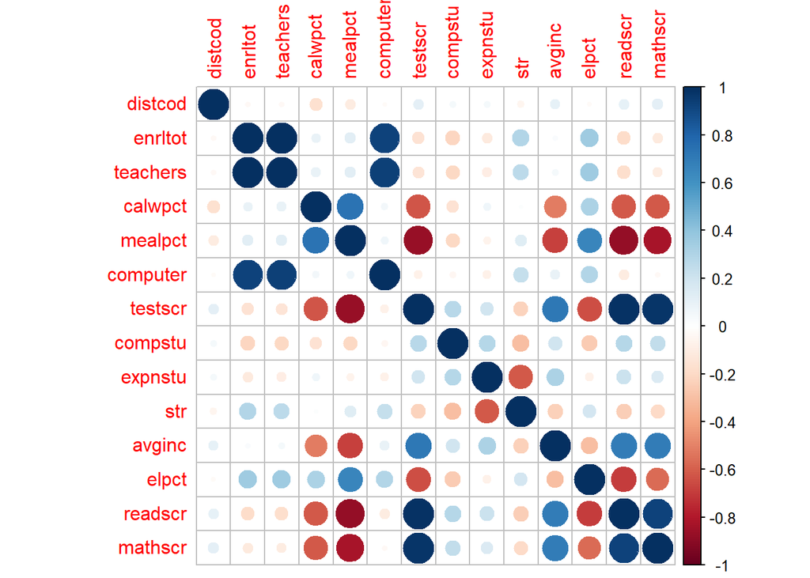

```r
## Seleccionamos solo númericas:

casschol_numericos <- Caschool[,sapply(Caschool, is.numeric)]
corrplot(cor(casschol_numericos))
```

## y el Correlograma de los datos:

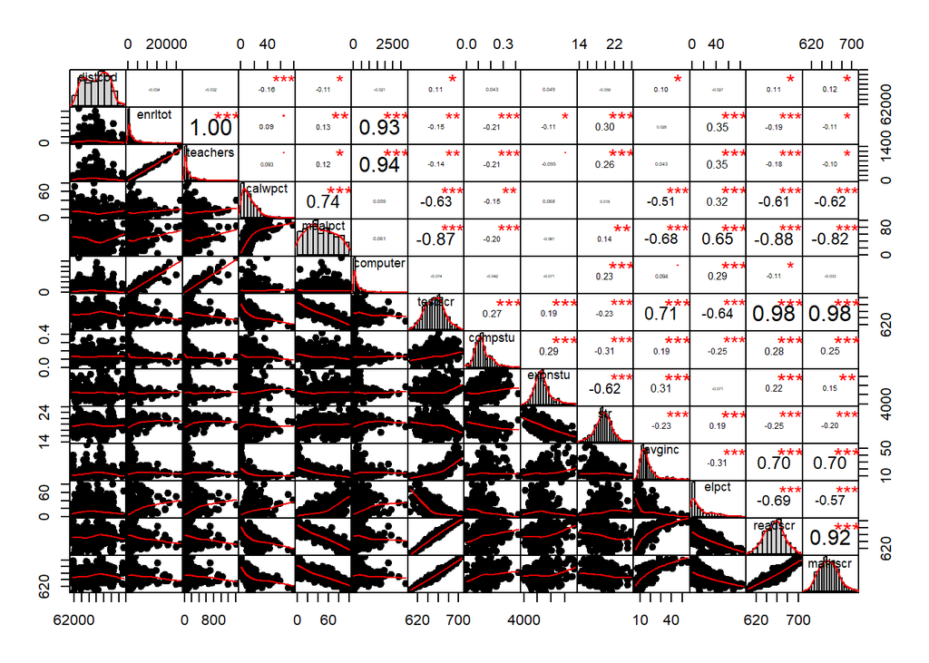

```r
suppressWarnings(chart.Correlation(casschol_numericos, histogram=TRUE, pch=19))
```

Se observa que la varible *testscr* presenta una fuerte correlación con las variables *calwptc*, *melaptc*, *avginc*, *elptc*, *readscr* y *mathscr*. En el correlograma además se esboza la tendencia o tipo de relación que puede haber entre las variables (lineal, cuadrática, etc)

##### Construimos nuestro primer modelo

```r
modelo1 <- lm( testscr  ~ . -distcod -county -district, data = Caschool  )
```

```r
summary(modelo1)
```

```
##
## Call:
## lm(formula = testscr ~ . - distcod - county - district, data = Caschool)
##
## Residuals:
##        Min         1Q     Median         3Q        Max
## -4.158e-05 -1.703e-05  1.570e-07  2.313e-05  4.065e-05
##
## Coefficients:
##               Estimate Std. Error    t value Pr(>|t|)
## (Intercept) -3.055e-05  9.268e-05 -3.300e-01  0.74189
## grspanKK-08  4.849e-06  3.204e-06  1.513e+00  0.13093
## enrltot     -4.907e-09  4.290e-09 -1.144e+00  0.25338
## teachers     1.409e-07  9.475e-08  1.488e+00  0.13765
## calwpct      5.467e-09  1.526e-07  3.600e-02  0.97144
## mealpct     -1.427e-07  1.096e-07 -1.303e+00  0.19347
## computer    -2.120e-08  8.165e-09 -2.597e+00  0.00974 **
## compstu      3.496e-05  2.024e-05  1.727e+00  0.08494 .
## expnstu      3.945e-10  2.421e-09  1.630e-01  0.87065
## str          6.195e-07  8.487e-07  7.300e-01  0.46587
## avginc       3.818e-08  2.464e-07  1.550e-01  0.87695
## elpct        2.598e-07  1.001e-07  2.596e+00  0.00976 **
## readscr      5.000e-01  1.919e-07  2.605e+06  < 2e-16 ***
## mathscr      5.000e-01  1.586e-07  3.153e+06  < 2e-16 ***
## ---
## Signif. codes:  0 '***' 0.001 '**' 0.01 '*' 0.05 '.' 0.1 ' ' 1
##
## Residual standard error: 2.187e-05 on 406 degrees of freedom
## Multiple R-squared:      1,  Adjusted R-squared:      1
## F-statistic: 2.445e+13 on 13 and 406 DF,  p-value: < 2.2e-16
```

**En la descripcion de nuestro dataset, se nos dice que la variable *testscr* es combinación de las variables *readscr* y *mathscr* por lo que debemos sacarlas de nuestro modelo**

Seleccionamos las variables a utilizar con el metodo *backward*, comenzamos con un modelo full y exploramos quitando variables hasta llegar al modelo que mejor ajuste

```r
lm_all <- lm(formula = testscr ~ . - distcod - county - district -readscr - mathscr, data = Caschool)
lm_null <- lm(testscr~ 1, data = Caschool)
testscr_fit_bwd <- step(lm_all, lm_null, direction = 'backward')
```

```
## Start:  AIC=1793.23
## testscr ~ (distcod + county + district + grspan + enrltot + teachers +
##     calwpct + mealpct + computer + compstu + expnstu + str +
##     avginc + elpct + readscr + mathscr) - distcod - county -
##     district - readscr - mathscr
##
##            Df Sum of Sq   RSS    AIC
## - teachers  1       0.1 28359 1791.2
## - enrltot   1       3.4 28363 1791.3
## - str       1      20.5 28380 1791.5
## - computer  1      51.6 28411 1792.0
## - compstu   1      99.9 28459 1792.7
## <none>                  28359 1793.2
## - expnstu   1     135.9 28495 1793.2
## - calwpct   1     175.0 28534 1793.8
## - grspan    1     617.4 28977 1800.3
## - elpct     1    2621.6 30981 1828.4
## - avginc    1    3306.6 31666 1837.5
## - mealpct   1    6765.0 35124 1881.1
##
## Step:  AIC=1791.23
## testscr ~ grspan + enrltot + calwpct + mealpct + computer + compstu +
##     expnstu + str + avginc + elpct
##
##            Df Sum of Sq   RSS    AIC
## - str       1      27.0 28386 1789.6
## - enrltot   1      59.3 28419 1790.1
## - computer  1      65.2 28425 1790.2
## - compstu   1     102.6 28462 1790.8
## <none>                  28359 1791.2
## - expnstu   1     137.0 28496 1791.3
## - calwpct   1     175.0 28534 1791.8
## - grspan    1     620.9 28980 1798.3
## - elpct     1    2622.2 30982 1826.4
## - avginc    1    3365.4 31725 1836.3
## - mealpct   1    6777.4 35137 1879.2
##
## Step:  AIC=1789.63
## testscr ~ grspan + enrltot + calwpct + mealpct + computer + compstu +
##     expnstu + avginc + elpct
```

[output cut: 26 more lines]

```
## - mealpct  1    7004.6 35459 1879.1
##
## Step:  AIC=1786.68
## testscr ~ grspan + calwpct + mealpct + compstu + expnstu + avginc +
##     elpct
##
##           Df Sum of Sq   RSS    AIC
## <none>                 28458 1786.7
## - calwpct  1     158.1 28616 1787.0
## - compstu  1     248.0 28706 1788.3
## - expnstu  1     295.7 28753 1789.0
## - grspan   1     585.1 29043 1793.2
## - elpct    1    2938.9 31397 1826.0
## - avginc   1    3497.8 31955 1833.4
## - mealpct  1    7036.1 35494 1877.5
```

La selección automatica de variables nos indica que las variables *grspan*, *calwpct*, *mealpct*, *compstu*, *expnstu*, *avginc* y *elpct* son las más importantes para nuestro modelo

Examinamos este modelo:

```r
summary(testscr_fit_bwd)
```

```
##
## Call:
## lm(formula = testscr ~ grspan + calwpct + mealpct + compstu +
##     expnstu + avginc + elpct, data = Caschool)
##
## Residuals:
##      Min       1Q   Median       3Q      Max
## -31.5944  -5.1119   0.0765   5.0333  26.3816
##
## Coefficients:
##               Estimate Std. Error t value Pr(>|t|)
## (Intercept)  6.585e+02  3.948e+00 166.807  < 2e-16 ***
## grspanKK-08 -3.478e+00  1.195e+00  -2.910   0.0038 **
## calwpct     -8.582e-02  5.673e-02  -1.513   0.1311
## mealpct     -3.620e-01  3.586e-02 -10.093  < 2e-16 ***
## compstu      1.283e+01  6.773e+00   1.895   0.0588 .
## expnstu      1.536e-03  7.423e-04   2.069   0.0392 *
## avginc       6.182e-01  8.687e-02   7.116 4.96e-12 ***
## elpct       -2.167e-01  3.322e-02  -6.523 2.02e-10 ***
## ---
## Signif. codes:  0 '***' 0.001 '**' 0.01 '*' 0.05 '.' 0.1 ' ' 1
##
## Residual standard error: 8.311 on 412 degrees of freedom
## Multiple R-squared:  0.8129, Adjusted R-squared:  0.8097
## F-statistic: 255.7 on 7 and 412 DF,  p-value: < 2.2e-16
```

**Sin embargo notamos que hay variables que no son significativas como *calwptc*, *compstu* e inclusive *expnstu***

### Construimos un nuevo modelo tomando el polinomio grado 3 de la variable *calwptc* y quitando a la variable *compstu*:

```r
modelo_final <- lm( testscr  ~   grspan  + mealpct +  avginc + elpct +expnstu+ poly(calwpct,3), data = Caschool  )
summary(modelo_final)
```

```
##
## Call:
## lm(formula = testscr ~ grspan + mealpct + avginc + elpct + expnstu +
##     poly(calwpct, 3), data = Caschool)
##
## Residuals:
##      Min       1Q   Median       3Q      Max
## -30.8845  -5.3450  -0.2118   4.8400  28.6469
##
## Coefficients:
##                     Estimate Std. Error t value Pr(>|t|)
## (Intercept)        6.581e+02  4.245e+00 155.004  < 2e-16 ***
## grspanKK-08       -3.551e+00  1.199e+00  -2.962  0.00324 **
## mealpct           -3.499e-01  3.980e-02  -8.790  < 2e-16 ***
## avginc             5.663e-01  9.020e-02   6.277 8.76e-10 ***
## elpct             -2.258e-01  3.365e-02  -6.711 6.43e-11 ***
## expnstu            1.817e-03  7.201e-04   2.524  0.01199 *
## poly(calwpct, 3)1 -3.073e+01  1.541e+01  -1.995  0.04673 *
## poly(calwpct, 3)2  3.494e+00  1.053e+01   0.332  0.74030
## poly(calwpct, 3)3 -2.424e+01  8.964e+00  -2.704  0.00714 **
## ---
## Signif. codes:  0 '***' 0.001 '**' 0.01 '*' 0.05 '.' 0.1 ' ' 1
##
## Residual standard error: 8.284 on 411 degrees of freedom
## Multiple R-squared:  0.8146, Adjusted R-squared:  0.811
## F-statistic: 225.7 on 8 and 411 DF,  p-value: < 2.2e-16
```

La bondad de ajuste ha aumentado un poco, por lo que parece que nuestro modelo tendrá un **mejor** desempeño.

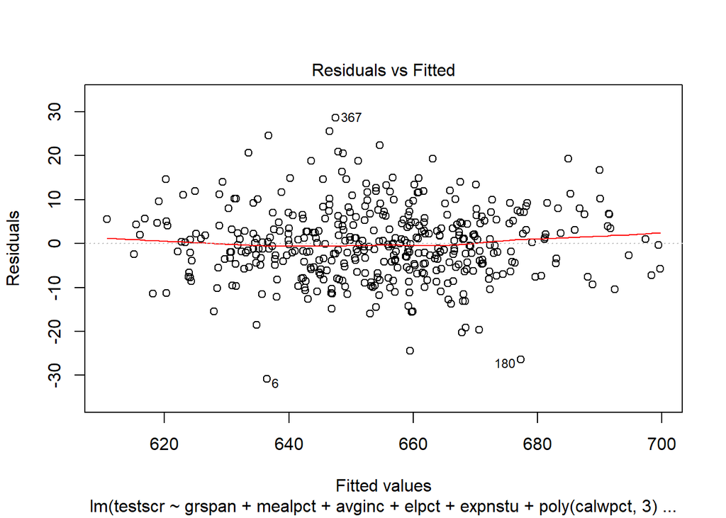

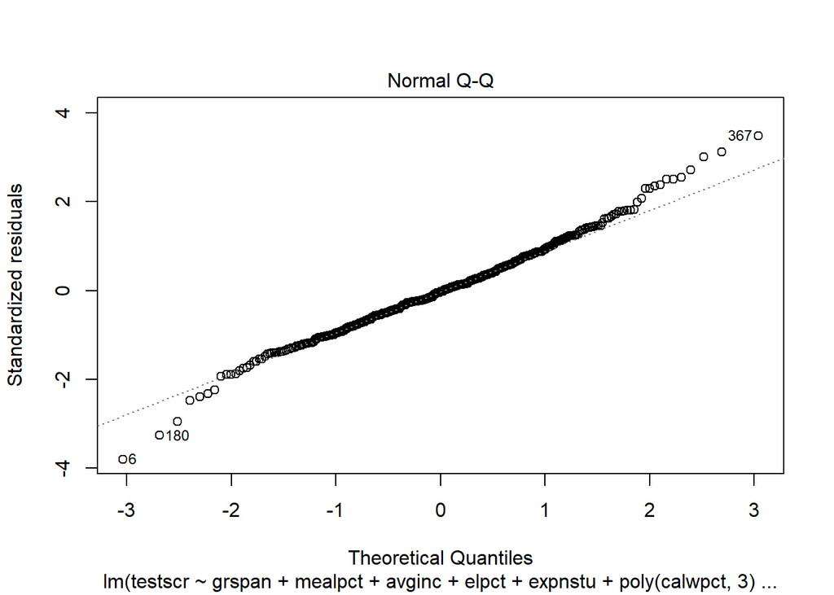

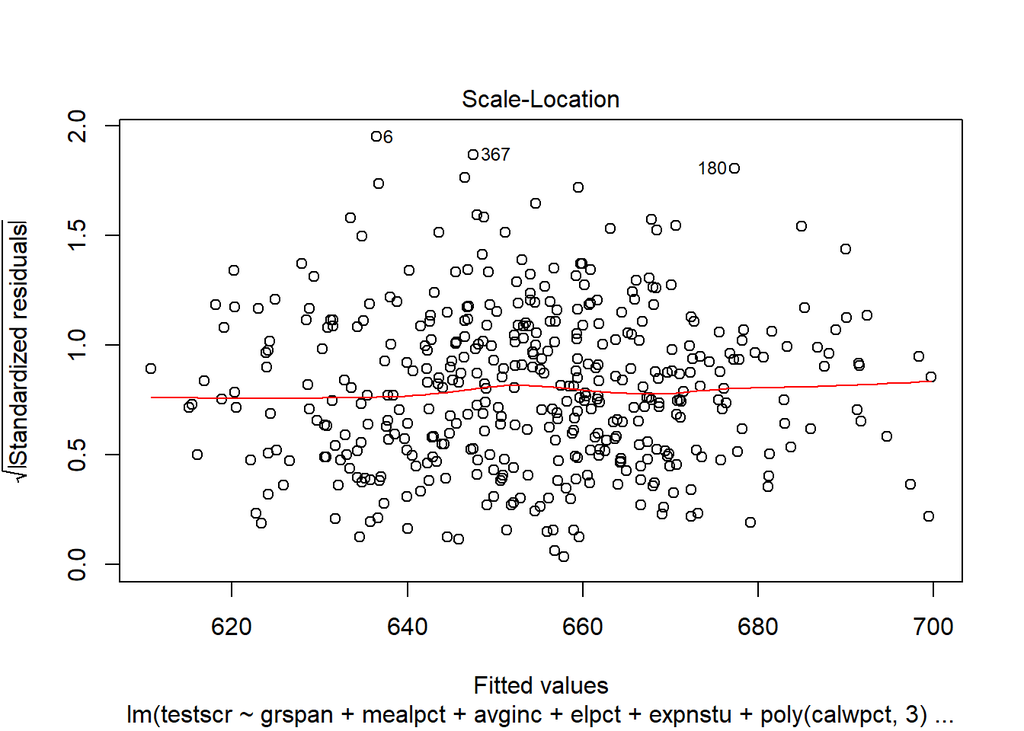

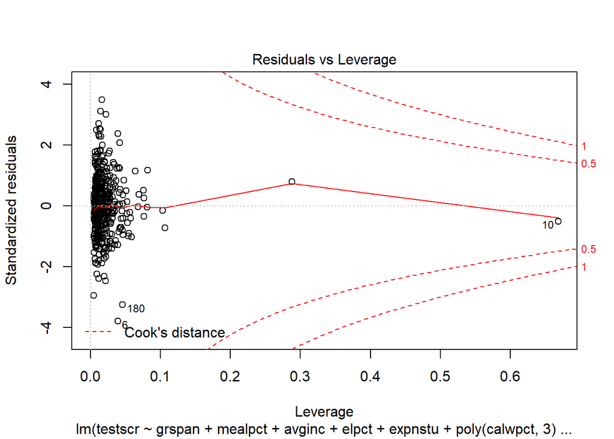

```r
plot(modelo_final)
```

No parece haber problemas con nuestro modelo.

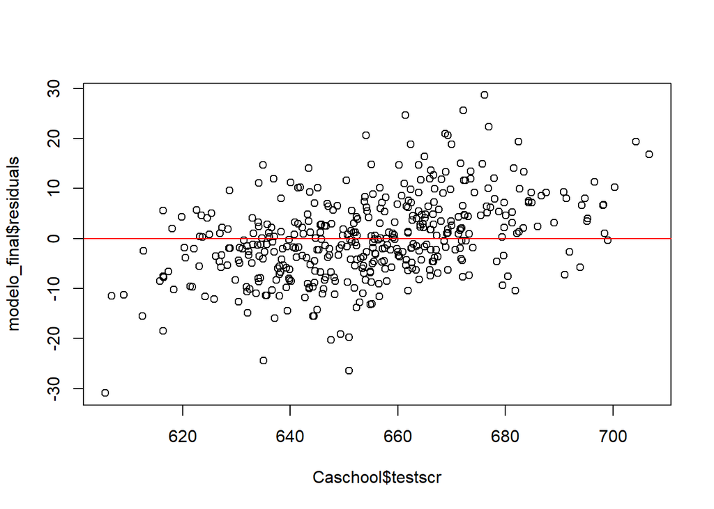

```r
plot(Caschool$testscr, modelo_final$residuals)
abline(0,0, col = "red")
```

Revisamos la colinealidad:

```r
vif(modelo_final)
```

```
##                      GVIF Df GVIF^(1/(2*Df))
## grspan           1.092399  1        1.045179
## mealpct          7.117314  1        2.667830
## avginc           2.594279  1        1.610677
## elpct            2.311366  1        1.520318
## expnstu          1.272611  1        1.128101
## poly(calwpct, 3) 4.634554  3        1.291223
```

**No** hay colinealidad en las variables seleccionadas

#### Por Ultimo Estudiamos la presencia de high-leverage points:

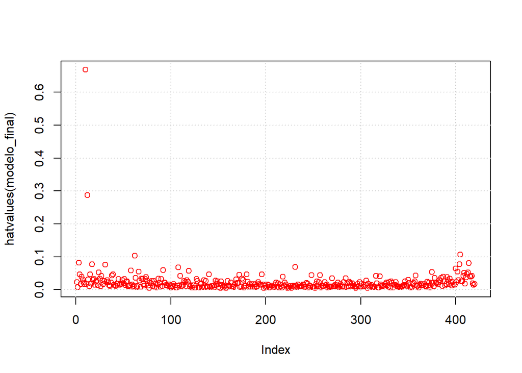

```r
plot(hatvalues(modelo_final), col = 'red')
grid()
```

#### En la construcción del modelo del ejercicio anterior habrás pasado por varios modelos intermedios. Considera el modelo final y un par de esos modelos intermedios y, mediante leave-one-out cross-validation y 10-fold cross-validation, estima su capacidad predictiva en situaciones reales y justifica si tu elección en el ejercicio anterior era acertada o no.

## Con LOOCV

- Modelo 1 con todas las variables
- Modelo 2 con las variables que recomienda el modelo con *stepwise*
- Modelo 3 nuestro modelo final

```r
# LOOCV
err_1 <- c()
err_2 <- c()
err_3 <- c()
for(i in 1:nrow(Caschool)){
  modelo_1 <- lm(testscr ~ grspan + enrltot +teachers+ calwpct + mealpct + computer + compstu + expnstu + str + avginc + elpct,    data = Caschool[-i,])
  modelo_2 <- lm(testscr ~ grspan + calwpct + mealpct + compstu + expnstu + avginc + elpct, data = Caschool[-i,])
  modelo_3 <- lm(testscr  ~   grspan  + mealpct +  avginc + elpct+ expnstu+ poly(calwpct,3), data = Caschool[-i,])
  err_1 <- c(err_1, (Caschool$testscr[i] - predict(modelo_1, Caschool[i,]))**2)
  err_2 <- c(err_2,  (Caschool$testscr[i] - predict(modelo_2,Caschool[i,]))**2)
  err_3 <- c(err_3,  (Caschool$testscr[i] - predict(modelo_3, Caschool[i,]))**2)
}
mean(err_1)
```

```
## [1] 71.44037
```

```r
mean(err_2)
```

```
## [1] 70.52889
```

```r
mean(err_3)
```

```
## [1] 69.93592
```

Con este LOOCV observamos que el modelo que tiene más error es el modelo 1 que corresponde al modelo con todas las variables, mientras el mejor modelo es el nuestro.

El grafico comparativo:

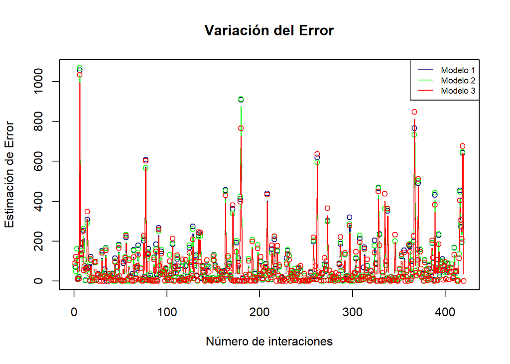

```r
plot(err_1, col="navy", type="b", ylim=c(min(err_1,err_2,err_3), max(err_1,err_2,err_3)+ 0.05), main = "Variación del Error", xlab="Número de interaciones", ylab = "Estimación de Error")
points(err_2, col="green", type = "b")
points(err_3, col="red", type = "b")
legend("topright", legend = c("Modelo 1", "Modelo 2", "Modelo 3"), col = c("navy","green","red"), lty = 1, lwd= 1, cex = .7)
```

# Con k-fold CV ( k = 10)

```r
set.seed(1)
fold_index_list <- createFolds(Caschool$testscr, k = 10)
mat_err <- matrix(nrow = 0, ncol = 6)
colnames(mat_err) <- c('mse_train_1', 'mse_test_1', 'mse_train_2', 'mse_test_2', 'mse_train_3', 'mse_test_3')
for(fold in fold_index_list){
  training_data <- Caschool[-fold, ]
  test_data <- Caschool[fold, ]
  modelo_1 <- lm(testscr ~ grspan + enrltot + calwpct + teachers+ mealpct + computer + compstu + expnstu + str + avginc + elpct,    data = Caschool[-i,])
  modelo_2 <- lm(testscr ~ grspan + calwpct + mealpct + compstu + expnstu + avginc + elpct, data = Caschool[-i,])
  modelo_3 <- lm(testscr  ~   grspan  + mealpct +  avginc + elpct+ expnstu+ poly(calwpct,3), data = Caschool[-i,])
  mse_train_1 <- mean((modelo_1$residuals)**2)
  mse_train_2 <- mean((modelo_2$residuals)**2)
  mse_train_3 <- mean((modelo_3$residuals)**2)
  mse_test_1 <- mean((test_data$testscr - predict(modelo_1, test_data))**2)
  mse_test_2 <- mean((test_data$testscr - predict(modelo_2, test_data))**2)
  mse_test_3 <- mean((test_data$testscr - predict(modelo_3, test_data))**2)
  mat_err <- rbind(mat_err, c(mse_train_1,
                      mse_test_1,
                      mse_train_2,
                      mse_test_2,
                      mse_train_3,
                      mse_test_3))
}
mat_err <- as.data.frame(mat_err)
colMeans(mat_err)
```

```
## mse_train_1  mse_test_1 mse_train_2  mse_test_2 mse_train_3  mse_test_3
##    67.68307    67.56785    67.91744    67.79755    67.30738    67.19417
```

```r
err_1<- mat_err$mse_test_1
err_2<- mat_err$mse_test_2
err_3<- mat_err$mse_test_3
```

Graficamente:

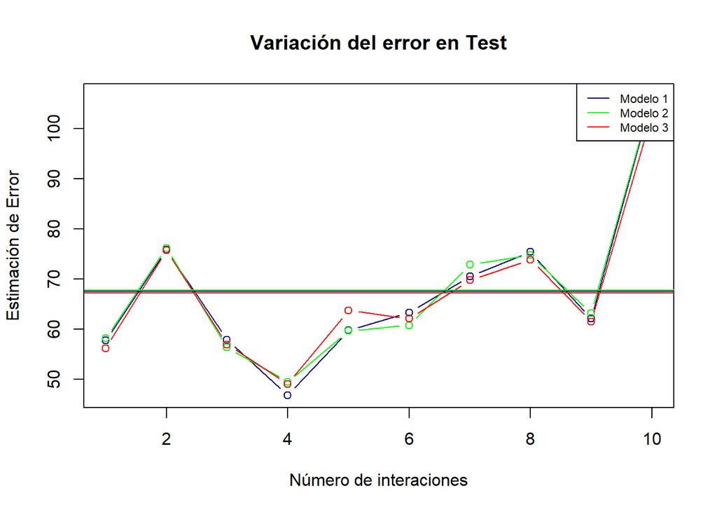

```r
plot(err_1, col="navy", type="b", ylim=c(min(err_1,err_2,err_3), max(err_1,err_2,err_3)+ 0.05), main = "Variación del error en Test", xlab="Número de interaciones", ylab = "Estimación de Error")
points(err_2, col="green", type = "b")
points(err_3, col="red", type = "b")
legend("topright", legend = c("Modelo 1", "Modelo 2", "Modelo 3"), col = c("navy","green","red"), lty = 1, lwd= 1, cex = .7)
abline(h=mean(err_1), col="navy")
abline(h=mean(err_2), col="green")
abline(h=mean(err_3), col="red")
```